# Práctica 1: Hechos estilizados sobre el comportamiento del precio y el rendimiento de los activos

## Hecho II: Cluster de Volatilidad

La magnitud de los rendimientos sí tiene memoria: si el mercado tuvo un día muy volátil, es más probable que el día siguiente también lo sea, sin importar si el movimiento fue positivo o negativo. Esto nos muestra que los rendimientos no son independientes.

**Mostrar código**

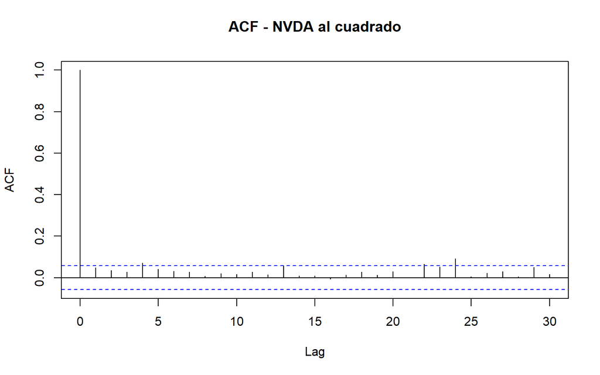

```r
acf(as.numeric(na.omit(log_return$NVDA))^2, main = "ACF - NVDA al cuadrado")
```

**Mostrar código**

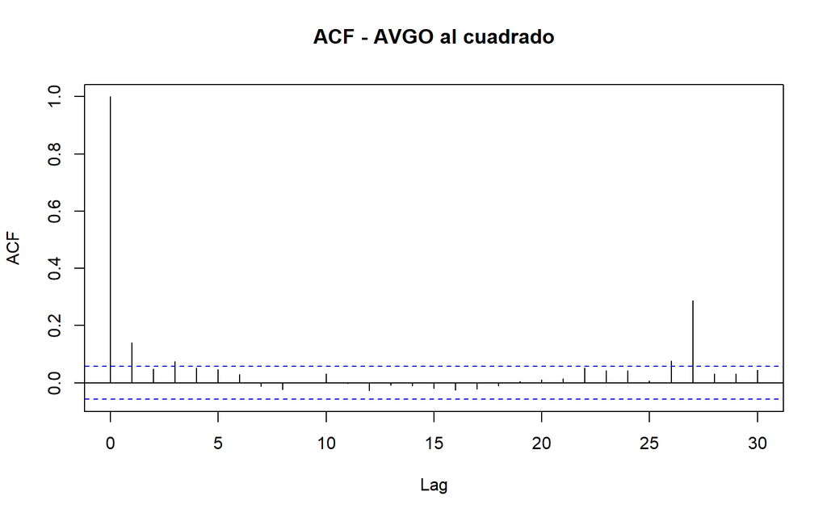

```r
acf(as.numeric(na.omit(log_return$AVGO))^2, main = "ACF - AVGO al cuadrado")
```

**Mostrar código**

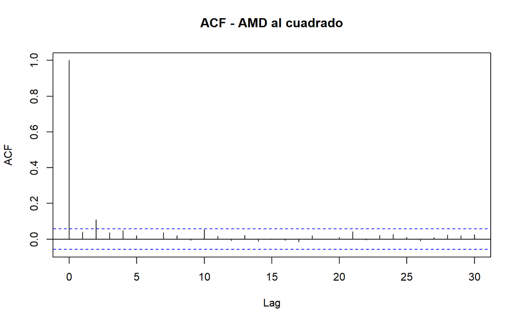

```r
acf(as.numeric(na.omit(log_return$AMD))^2,  main = "ACF - AMD al cuadrado")
```

Tomando en cuenta la gráfica de AVGO, ya que NVDA tiene evidencia de clustering de volatilidad débil y no muy concluyente, sí hay evidencia más clara de clustering de volatilidad, particularmente en el corto plazo.

## Hecho III: Colas Pesadas

la distribución de los rendimientos financieros no es normal ya que tiene colas más pesadas que la distribución normal: eventos extremos (grandes ganancias o pérdidas) ocurren con mayor frecuencia y mayor curtosis, contradiciendo el supuesto clásico de que los rendimientos siguen una distribución normal.

**Mostrar código**

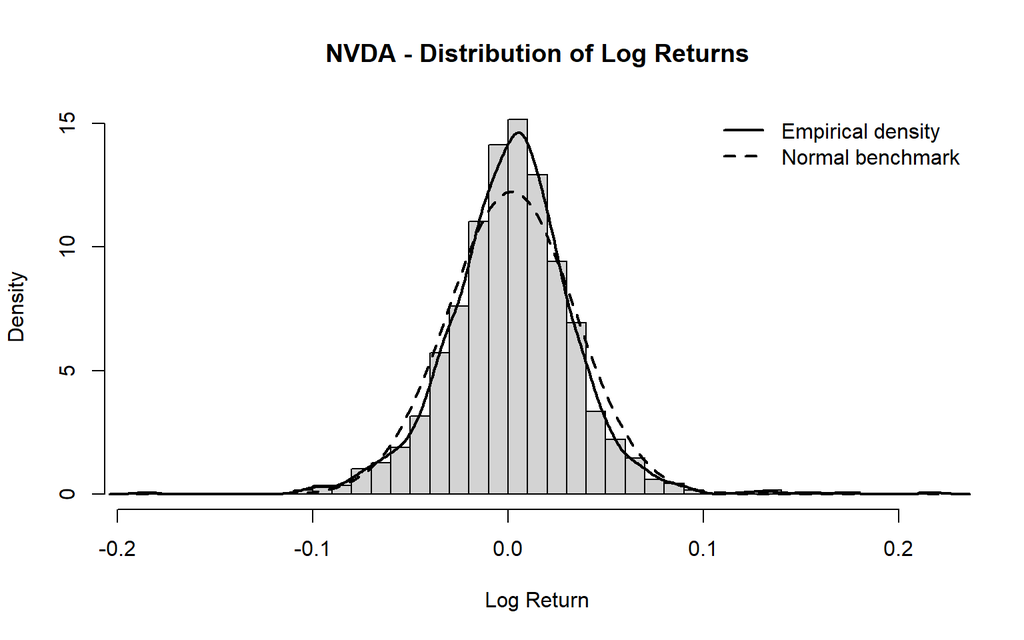

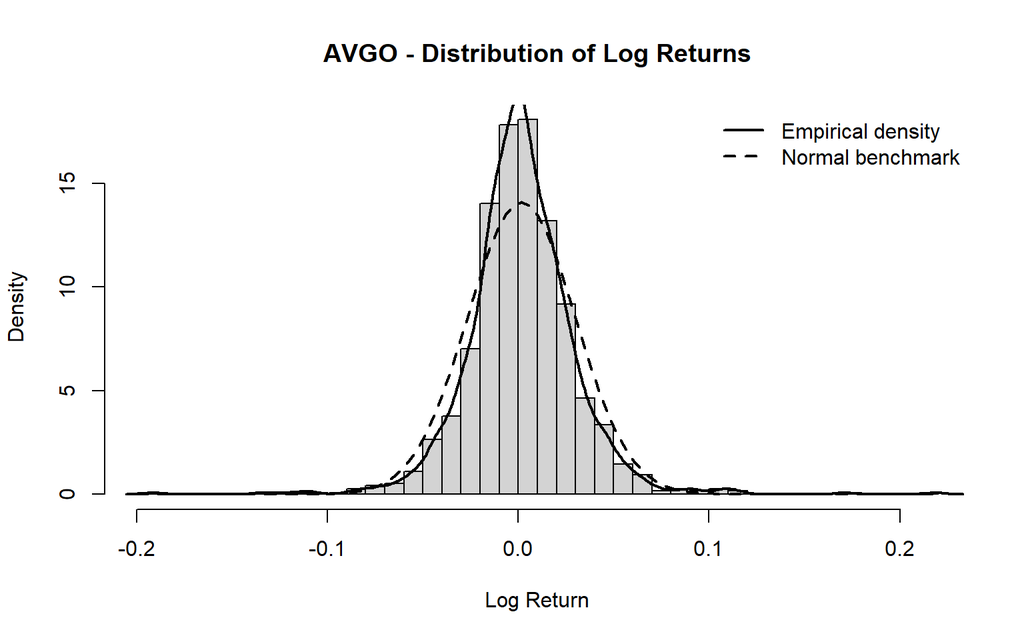

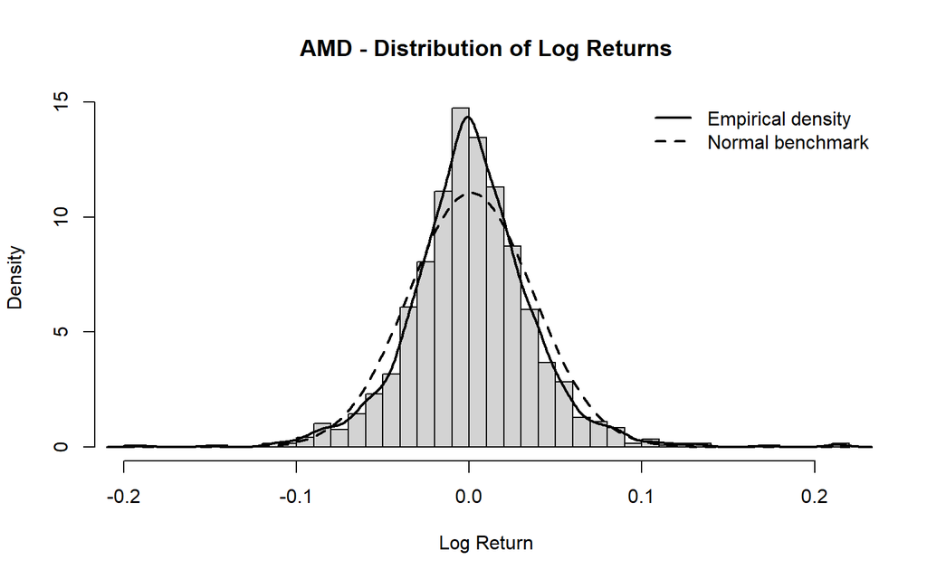

```r
par(mfrow = c(1, 1))

for (t in ticker) {

  r <- as.numeric(na.omit(log_return[, t]))

  hist(
    r,
    breaks = 50,
    probability = TRUE,
    main = paste(t, "- Distribution of Log Returns"),
    xlab = "Log Return"
  )

  lines(
    density(r),
    lwd = 2
  )

  mu_hat    <- mean(r)
  sigma_hat <- sd(r)

  curve(
    dnorm(x, mean = mu_hat, sd = sigma_hat),
    add = TRUE,
    lwd = 2,
    lty = 2
  )

  legend(
    "topright",
    legend = c("Empirical density", "Normal benchmark"),
    lty = c(1, 2),
    lwd = c(2, 2),
    bty = "n"
  )

}
```

**Mostrar código**

```r
par(mfrow = c(1, 1))
```

Las 3 gráficas de los Activos muestran comportamiento de este tipo teniendo colas pesadas y mayor curtosis.